# CTA1 promoter bashing

JY

2023-11-24 (updated 2024-01-03)

```r
library(tidyverse)
library(ggtext)
#library(mgcv)
#library(broom)
library(cowplot)
```

## Goal

Plot the dynamics for CTA1 promoter bashing variants under - Pi and 2 mM H2O2 treatment

## Common plotting functions

**Update 2022-11-08** This list is used as a shared plotting set up.

```r
p.timecourse <- list(
  stat_summary(fun = "mean", geom = "point", size = 3),
  stat_summary(fun.data = "mean_cl_boot", geom = "errorbar", width = 3),
  stat_smooth(aes(size = Genotype == "WT"), method = "loess",
              formula = 'y~x', se = FALSE),
  scale_x_continuous(breaks = seq(0,240,30)),
  scale_size_manual(values = c(0.8, 1.5), guide = "none"),
  labs(x = "Time (min)", y = "Cta1-GFP protein level (a.u.)"),
  theme_cowplot(line_size = 0.7, font_size = 14),
  theme(legend.position=c(0.05,0.75),
        #legend.box.background = element_rect(color = "black"),
        #legend.box.margin = margin(3,3,3,3),
        legend.text = element_text(face = 3),
        legend.title = element_text(),
        axis.title = element_text(size = rel(1)),
        #axis.title.x = element_blank(),
        axis.text.x = element_text(hjust=0.5), axis.text = element_text(size = rel(1)),
  )
)
```

## CTA1 induction in OL variants

#### -Pi Data

Import data and get the replicate, time and genotype info

```r
files <- dir("input/OL_0Pi", pattern = "d01*") # get the file names of the merged
files <- file.path("input//OL_0Pi", files)         # this appends the directory to the file names
names(files) <- c("Rep1-0Pi-Ctrl","Rep2-0Pi-Ctrl", "Rep3-0Pi-Ctrl")

tp <- c("0min",  "30min", "60min", "90min", "120min", "150min",  "180min", "210min", "240min") # ordered time points

# import and process the data to the format we want
data.ol.pi <- map_dfr(files, ~read_csv(., na = c("", "NA", "N/A"), col_types = cols()), .id = "Replicate") %>%
  #bind_rows(.id = "Replicate") %>%
  filter(`X Parameter` == "BL1-H", is.na(`Y Parameter`)) %>%
  select(Replicate, Group, Sample, Count, median = `X Median`, peak = `X Peak`,
         sd = `X SD`, cv = `X %CV`, rCV = `X %rCV`) %>%
  separate(Group, into = c('Time', 'Treatment'), sep = "-") %>%
  mutate(Time = ordered(Time, levels = tp)) %>%
  mutate(Sample = case_when(Sample == "CTA1-GFP-yH298" ~ "yH298-wt",
            Sample == "CTA1-GFP-yH299" ~ "yH299-wt",
            Sample == "yH343-wt" ~ "yH343-rescue",
            Sample == "yH344-wt" ~ "yH344-rescue",
            TRUE ~ Sample)) %>%
  mutate(Replicate = gsub("\\-.*","", Replicate)) %>% #
  separate(Sample, into = c("Strain", "genotype"), sep = "-") %>%
  arrange(Time)
# To replace the value: ifelse() for a single test, case_when() for multiple test
# \\-: escape character "\\" used to escape the special meaning of -, instead take - as a common regex pattern. Or we can specify the - as a regex pattern within a square bracket class [-]
#.*: This part matches any sequence of characters (.* is a common regex pattern for "any character, zero or more times"). metacharacter
```

#### under -Pi

Plot the internal removal variants data(OL)

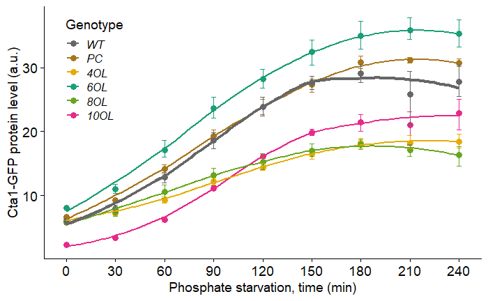

```r
# recode the genotype
levels <- c(WT = "wt", PC = "rescue",`4OL` = "4OL", `6OL` = "6OL", `8OL` = "8OL", `10OL` = "10OL")

pi.dat <- data.ol.pi %>%
  filter(genotype %in% c("wt", "4OL", "6OL", "8OL", "10OL","rescue")) %>%
  select(Time, replicate = Replicate, genotype, median) %>%
  mutate(Genotype = fct_recode(genotype, !!!levels)) %>%
  mutate(new_median =median/1000) %>%
  mutate(new_time = as.numeric(gsub("min","",Time)))%>%
  arrange(new_time, genotype, replicate)

genotype_color <- RColorBrewer::brewer.pal(8, "Dark2")[c(8, 7, 6, 1, 5, 4)]
names(genotype_color) <- names(levels)

pi.dat %>%
  filter(!is.na(new_median)) %>%
  ggplot(aes(x = new_time, y = new_median, color = Genotype)) + p.timecourse +
  scale_color_manual(values= genotype_color, limits = names(genotype_color)) +
  xlab("Phosphate starvation, time (min)")
```

```r
  #scale_y_continuous(limits = c(NA, 22))

#ggsave("output/OL_0Pi.png", width = 6, height = 8)
```

#### 2mM H2O2 Data

Import 2mM H2O2 OL data and get the replicate, time and genotype info

```r
files <- dir("input/OL_2mMH2O2", pattern = "d*") # get the file names of the merged
files <- file.path("input//OL_2mMH2O2", files)      # this appends the directory to the file names
names(files) <- c("Rep1-2mMH2O2","Rep2-2mMH2O2", "Rep3-2mMH2O2", "Rep4-2mMH2O2")

tp <- c("0min",  "30min", "60min", "90min", "120min", "150min",  "180min", "210min", "240min") # ordered time points

# import and process the data to the format we want
data.ol.oxi <- map_dfr(files, ~read_csv(., na = c("", "NA", "N/A"), col_types = cols()), .id = "Replicate") %>%
  #bind_rows(.id = "Replicate") %>%
  filter(`X Parameter` == "BL1-H", is.na(`Y Parameter`)) %>%
  select(Replicate, Group, Sample, Count, median = `X Median`, peak = `X Peak`,
         sd = `X SD`, cv = `X %CV`, rCV = `X %rCV`) %>%
  separate(Group, into = c('Time', 'Treatment'), sep = "-") %>%
  mutate(Time = ordered(Time, levels = tp)) %>%
  mutate(Sample = case_when(Sample == "CTA1-GFP-yH298" ~ "yH298-wt",
            Sample == "CTA1-GFP-yH299" ~ "yH299-wt",
            Sample == "yH343-wt" ~ "yH343-rescue",
            Sample == "yH344-wt" ~ "yH344-rescue",
            TRUE ~ Sample)) %>%
  mutate(Replicate = gsub("\\-.*","", Replicate)) %>% #
  separate(Sample, into = c("Strain", "genotype"), sep = "-") %>%
  arrange(Time)
# To replace the value: ifelse() for a single test, case_when() for multiple test
# \\-: escape character "\\" used to escape the special meaning of -, instead take - as a common regex pattern. Or we can specify the - as a regex pattern within a square bracket class [-]
#.*: This part matches any sequence of characters (.* is a common regex pattern for "any character, zero or more times"). metacharacter
```

#### under 2mM H2O2

Plot the internal removal variants data(OL)

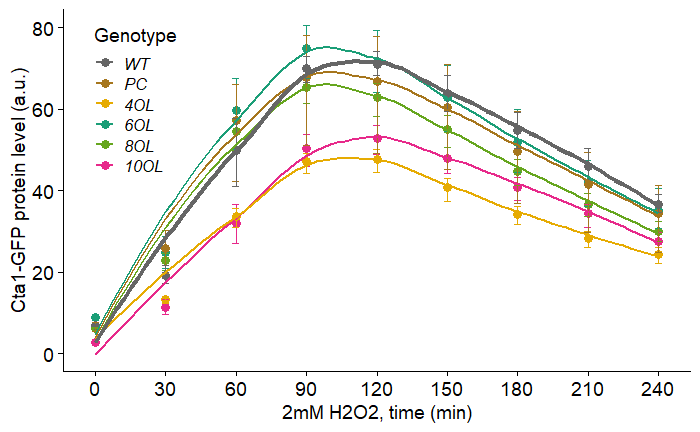

```r
# recode the genotype
levels <- c(WT = "wt", PC = "rescue",`4OL` = "4OL", `6OL` = "6OL", `8OL` = "8OL", `10OL` = "10OL")

oxi.ol.dat <- data.ol.oxi %>%
  filter(genotype %in% c("wt", "4OL", "6OL", "8OL", "10OL","rescue")) %>%
  select(Time, replicate = Replicate, genotype, median) %>%
  mutate(Genotype = fct_recode(genotype, !!!levels)) %>%
  mutate(new_median =median/1000) %>%
  mutate(new_time = as.numeric(gsub("min","",Time)))%>%
  arrange(new_time, genotype, replicate)

genotype_color <- RColorBrewer::brewer.pal(8, "Dark2")[c(8, 7, 6, 1, 5, 4)]
names(genotype_color) <- names(levels)

oxi.ol.dat %>%
  filter(!is.na(new_median)) %>%
  ggplot(aes(x = new_time, y = new_median, color = Genotype)) + p.timecourse +
  scale_color_manual(values= genotype_color, limits = names(genotype_color)) +
  xlab("2mM H2O2, time (min)")
```

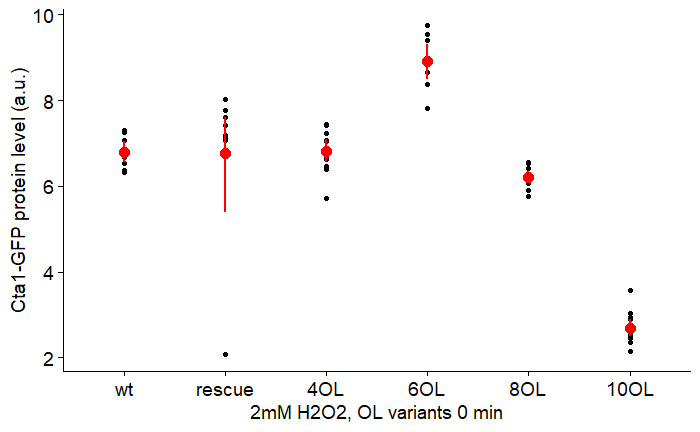

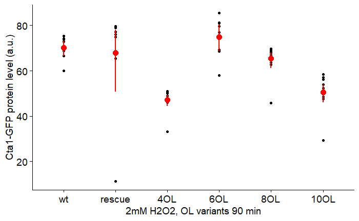

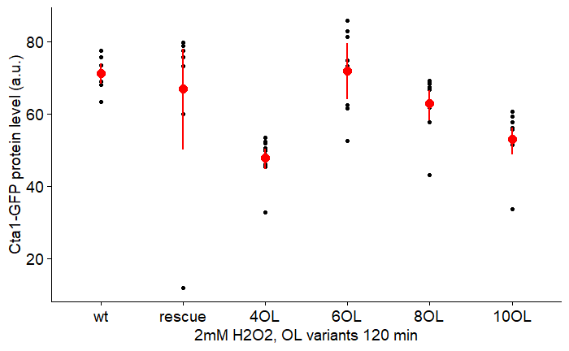

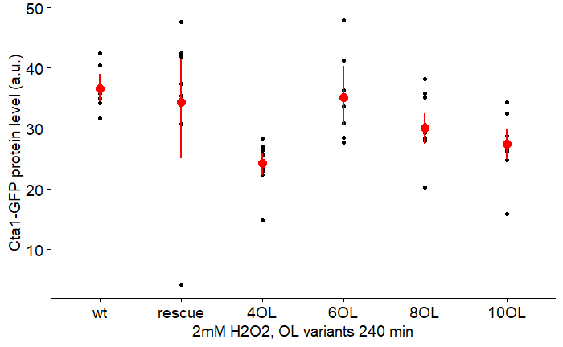

```r
  #scale_y_continuous(limits = c(NA, 22))

#ggsave("output/OL_oxi.png", width = 6, height = 8)


##### 2mM H2O2 OL timepoint plot function
tp_GFP <- function(...){

  all_tp <- list(...)
  for (input_tp in all_tp) {

    df_tp <- oxi.ol.dat %>% filter(new_time == input_tp) %>% mutate(genotype = factor(genotype, levels = levels))

    print(ggplot(df_tp, aes(x = genotype, y = new_median, fill = Genotype)) +
    geom_point() +
    stat_summary(fun.data = "mean_cl_boot", conf.int = .95, color = "Red", linewidth = 1, size = 0.8) +
    labs(x =paste0("2mM H2O2, OL variants ", deparse1(substitute(input_tp)), " min"), y = "Cta1-GFP protein level (a.u.)") +
    theme_cowplot(line_size = 0.7, font_size = 14) +
    theme(legend.position = "none",
          axis.title = element_text(size = rel(1)),
          axis.text.x = element_text(hjust=0.5), axis.text = element_text(size = rel(1)),))
  }
}

# plot the 2mM H2O2 OL variants at 0min, 90min, 120min timepoints

tp_GFP(0,90,120,240)
```

```r
NA
NA
```

### Import TrunV data and get the replicate, time and genotype info

```r
files <- dir("input/TrunV_0Pi", pattern = "d01*") # get the file names of the merged
files <- file.path("input//TrunV_0Pi", files)         # this appends the directory to the file names
names(files) <- c("Rep1-0Pi-Ctrl","Rep2-0Pi-Ctrl", "Rep3-0Pi-Ctrl")

tp <- c("0min",  "30min", "60min", "90min", "120min", "150min",  "180min", "210min", "240min") # ordered time points

# import and process the data to the format we want
data.TrunV <- map_dfr(files, ~read_csv(., na = c("", "NA", "N/A"), col_types = cols()), .id = "Replicate") %>%
  #bind_rows(.id = "Replicate") %>%
  filter(!is.na(median),`X Parameter` == "BL1-H", is.na(`Y Parameter`)) %>%
  select(Replicate, Group, Sample, Count, median = `X Median`, peak = `X Peak`,
         sd = `X SD`, cv = `X %CV`, rCV = `X %rCV`) %>%
  separate(Group, into = c('Time', 'Treatment'), sep = "-") %>%
  mutate(Time = ordered(Time, levels = tp)) %>%
  mutate(Sample = case_when(Sample == "CTA1-GFP-yH298" ~ "yH298-wt",
            Sample == "CTA1-GFP-yH299" ~ "yH299-wt",
            Sample == "yH343-wt" ~ "yH343-rescue",
            Sample == "yH344-wt" ~ "yH344-rescue",
            TRUE ~ Sample)) %>%
  mutate(Replicate = gsub("\\-.*","", Replicate)) %>%
  separate(Sample, into = c("Strain", "genotype"), sep = "-") %>%
  filter(!is.na(median)) %>%
  arrange(Time)
# To replace the value: ifelse() for a single test, case_when() for multiple test
# \\-: escape character "\\" used to escape the special meaning of -, instead take - as a common regex pattern. Or we can specify the - as a regex pattern within a square bracket class [-]
#.*: This part matches any sequence of characters (.* is a common regex pattern for "any character, zero or more times"). metacharacter
```

#### Plot the truncation variants data (TrunV)

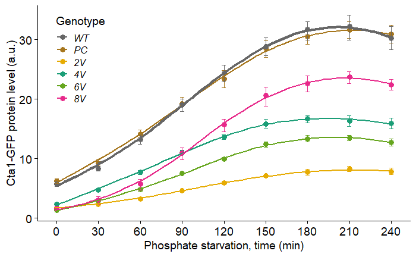

```r
# recode the genotype
levels <- c(WT = "wt", `PC` = "rescue", `2V` = "2V",`4V` = "4V", `6V` = "6V", `8V` = "8V")

pi.dat <- data.TrunV %>%
  filter(genotype %in% c("wt", "2V", "4V", "6V", "8V","rescue")) %>%
  select(Time, replicate = Replicate, genotype, median) %>%
  mutate(Genotype = fct_recode(genotype, !!!levels)) %>%
  mutate(new_median =median/1000) %>%
  mutate(new_time = as.numeric(gsub("min","",Time)))%>%
  arrange(new_time, genotype, replicate)

genotype_color <- RColorBrewer::brewer.pal(8, "Dark2")[c(8, 7, 6, 1, 5, 4)]
names(genotype_color) <- names(levels)

pi.dat %>%
  filter(!is.na(new_median)) %>%
  ggplot(aes(x = new_time, y = new_median, color = Genotype)) + p.timecourse +
  scale_color_manual(values= genotype_color, limits = names(genotype_color)) +
  xlab("Phosphate starvation, time (min)")
```

```r
  #scale_y_continuous(limits = c(NA, 22))

#ggsave("output/TrunV_0Pi.png", width = 6, height = 8)
```

#### 2mM H2O2 Data

Import 2mM H2O2 TrunV data and get the replicate, time and genotype info

```r
files <- dir("input/TrunV_2mMH2O2", pattern = "d*") # get the file names of the merged
files <- file.path("input//TrunV_2mMH2O2", files)      # this appends the directory to the file names
names(files) <- c("Rep1-2mMH2O2","Rep2-2mMH2O2", "Rep3-2mMH2O2")

tp <- c("0min",  "30min", "60min", "90min", "120min", "150min",  "180min", "210min", "240min") # ordered time points

# import and process the data to the format we want
data.TrunV.oxi <- map_dfr(files, ~read_csv(., na = c("", "NA", "N/A"), col_types = cols()), .id = "Replicate") %>%
  #bind_rows(.id = "Replicate") %>%
  filter(`X Parameter` == "BL1-H", is.na(`Y Parameter`)) %>%
  select(Replicate, Group, Sample, Count, median = `X Median`, peak = `X Peak`,
         sd = `X SD`, cv = `X %CV`, rCV = `X %rCV`) %>%
  separate(Group, into = c('Time', 'Treatment'), sep = "-") %>%
  mutate(Time = ordered(Time, levels = tp)) %>%
  mutate(Sample = case_when(Sample == "CTA1-GFP-yH298" ~ "yH298-wt",
            Sample == "CTA1-GFP-yH299" ~ "yH299-wt",
            Sample == "yH343-wt" ~ "yH343-rescue",
            Sample == "yH344-wt" ~ "yH344-rescue",
            TRUE ~ Sample)) %>%
  mutate(Replicate = gsub("\\-.*","", Replicate)) %>% #
  separate(Sample, into = c("Strain", "genotype"), sep = "-") %>%
  filter(!is.na(median)) %>%
  arrange(Time)
# To replace the value: ifelse() for a single test, case_when() for multiple test
# \\-: escape character "\\" used to escape the special meaning of -, instead take - as a common regex pattern. Or we can specify the - as a regex pattern within a square bracket class [-]
#.*: This part matches any sequence of characters (.* is a common regex pattern for "any character, zero or more times"). metacharacter
```